# BIOL-4315 Final Project

Gavin Ieong

2022-12-05

# Project: Comparing Alignment Results of Two Different Aligners (Bowtie2 and Hisat2)

## Preparations: Install all needed packages

This includes many packages from Bioconductor such as systemPipeR, and pheatmap. Furthermore, it includes an DEG analysis tool such as edgeR and deSeq2

```r
install.packages('docopt')
install.packages("DT")
install.packages('pheatmap')
BiocManager::install("Rbowtie")
BiocManager::install("GenomicFeatures")
BiocManager::install("DESeq2")
BiocManager::install("edgeR")
BiocManager::install("systemPipeR")
BiocManager::install("systemPipeRdata")
BiocManager::install("BiocStyle")
BiocManager::install("GO.db")
BiocManager::install("Rsubread")
```

Here we load the needed packages and also set up the enviroment $Path as Hisat2 and Bowtie 2 will be called from the terminal

```r
library(systemPipeRdata)
library(systemPipeR)

Sys.setenv(PATH="/opt/anaconda3/condabin:/opt/anaconda3/bin:/opt/anaconda3/lib:/usr/local/bin:/usr/bin:/bin:/usr/sbin:/sbin:/opt/X11/bin:/Library/Apple/usr/bin:/Users/Gavin/documents/hisat2-2.2.1:/Users/Gavin/documents/sratoolkit.2.11.3-mac64/bin:/Users/Gavin/documents/blast-2.13.0/bin:/Users/Gavin/documents/bowtie2")
system("echo $PATH")
```

use genWorkenvir() to create a new directory and workflow which will contain all the needed files and data for our project experiment

```r
getwd()
if(file.exists("rnaseq"))
   {
     print("Directory exists, skipping this step")
     }
   else{
     genWorkenvir(workflow = "rnaseq")
   }
```

Now we can start the project by creating a SRAproject().

**Note: CWL files contain the commands needed CWL define the parameters of a chosen command-line step or workflow, while files with the extension .yml define the input variables of command-line steps**

```r
targetspath <- "targetsPE.txt"
targets <- read.delim(targetspath, comment.char = "#")
DT::datatable(targets, options = list(scrollX = TRUE, autoWidth = TRUE))


finalProject <- SPRproject()
```

## Preprocess the reads.

After setting up our needed packages, libraries, and files, the first step is to preprocess the reads. To accomplish this task, we will first add a step to load systemPipeR into our project, then trim the reads with ShortReads, and output a fastq file Report to visualize read length, quality, etc

```r
## Step one, load SystemPipeR for project
appendStep(finalProject) <- LineWise(code = {
  library(systemPipeR)
}, step_name = "load_SPR")


## Step 2, preprocess the reads
appendStep(finalProject) <- SYSargsList(step_name = "preprocessing", targets = "targetsPE.txt",
                               dir = TRUE, wf_file = "preprocessReads/preprocessReads-pe.cwl",
                               input_file = "preprocessReads/preprocessReads-pe.yml", dir_path = "param/cwl",
                               inputvars = c(FileName1 = "_FASTQ_PATH1_", FileName2 = "_FASTQ_PATH2_", SampleName = "_SampleName_"),
                               dependency = c("load_SPR"))


## Step 3, print fastq_report on the reads
appendStep(finalProject) <- LineWise(code = {
  fastq <- getColumn(finalProject, step = "preprocessing", "targetsWF",
                     column = 1)
  fqlist <- seeFastq(fastq = fastq, batchsize = 10000, klength = 8)
  pdf("./results/fastqReport.pdf", height = 18, width = 4 *
        length(fqlist))
  seeFastqPlot(fqlist)
  dev.off()
}, step_name = "fastq_report", dependency = "preprocessing")
```

This is the report of our reads.

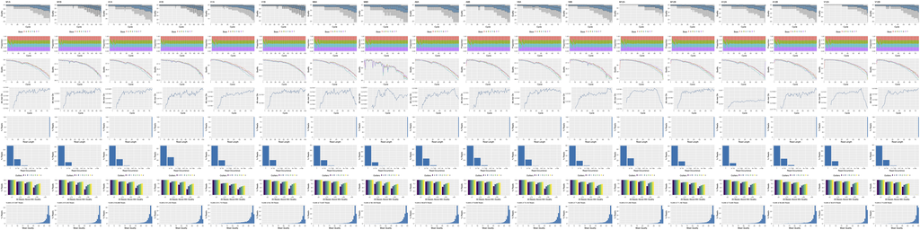

```r
knitr::include_graphics("png/fastqReport.png")
```

## Alignments (Indexing and Mapping) with Bowtie2 and Hisat2

After we have the needed reads, we must use an aligner to map and index before we can further examine them. The first aligner we will add to the project steps is Bowtie2. This is a two step proccess, as it will first index before mapping.

```r
## These two steps will index and map for Bowtie2
appendStep(finalProject) <- SYSargsList(step_name = "bowtie_index",  dir = FALSE,
                               targets = NULL,
                               wf_file = "bowtie2/bowtie2-idx/bowtie2-index.cwl",
                               input_file = "bowtie2/bowtie2-idx/bowtie2-index.yml",
                               dir_path = "param/cwl",
                               dependency = "preprocessing")

appendStep(finalProject) <- SYSargsList(step_name = "bowtie2_mapping",
                               dir = TRUE, targets = "preprocessing",
                               wf_file = "workflow-bowtie2/workflow_bowtie2-pe.cwl",
                               input_file = "workflow-bowtie2/workflow_bowtie2-pe.yml",
                               dir_path = "param/cwl",
                               inputvars=c(preprocessReads_1 = "_FASTQ_PATH1_", preprocessReads_2 = "_FASTQ_PATH2_", SampleName="_SampleName_"),
                               rm_targets_col = c("FileName1","FileName2"),
                               dependency = c("bowtie_index"))
```

The next aligner is Hisat2, and once again it is a two step process with indexing before mapping.

```r
## These two steps will create a index and mapping for hisat2
appendStep(finalProject) <- SYSargsList(step_name = "hisat2_index", dir = FALSE,
                               targets = NULL, wf_file = "hisat2/hisat2-index.cwl", input_file = "hisat2/hisat2-index.yml",
                               dir_path = "param/cwl", dependency = "preprocessing")


appendStep(finalProject) <- SYSargsList(step_name = "hisat2_mapping",
                               dir = TRUE, targets = "preprocessing", wf_file = "workflow-hisat2/workflow_hisat2-pe.cwl",
                               input_file = "workflow-hisat2/workflow_hisat2-pe.yml", dir_path = "param/cwl",
                               inputvars = c(preprocessReads_1 = "_FASTQ_PATH1_", preprocessReads_2 = "_FASTQ_PATH2_",
                                             SampleName = "_SampleName_"), rm_targets_col = c("FileName1",
                                                                                              "FileName2"), dependency = c("hisat2_index"))
```

After indexing and mapping is done for both aligners, we can check the alignment stats for each. We will put those stats into a file called **alignStats.xls** and this will be one of the ways to compare the results.

```r
appendStep(finalProject) <- LineWise(code = {
  fqpaths <- getColumn(finalProject, step = "preprocessing", "targetsWF",
                       column = "FileName1")
  bampaths <- getColumn(finalProject, step = "bowtie2_mapping", "outfiles",
                        column = "samtools_sort_bam")
  read_statsDF <- alignStats(args = bampaths, fqpaths = fqpaths,
                             pairEnd = TRUE)
  write.table(read_statsDF, "results/bowtie2_alignStats.xls", row.names = FALSE,
              quote = FALSE, sep = "\t")
}, step_name = "bowtie2_align_stats", dependency = "bowtie2_mapping")


appendStep(finalProject) <- LineWise(code = {
  fqpaths <- getColumn(finalProject, step = "preprocessing", "targetsWF",
                       column = "FileName1")

  bampaths <- getColumn(finalProject, step = "hisat2_mapping", "outfiles",
                        column = "samtools_sort_bam")

  read_statsDF <- alignStats(args = bampaths, fqpaths = fqpaths,
                             pairEnd = TRUE)
  write.table(read_statsDF, "results/hisat2_alignStats.xls", row.names = FALSE,
              quote = FALSE, sep = "\t")
}, step_name = "hisat2_align_stats", dependency = "hisat2_mapping")
```

Next, we will output the sample data and compare the alignment rates. We see that the alignment numbers and percentage is lower for bowtie2 in comparision to hisat2.

```r
read.table("results/bowtie2_alignStats.xls", header = TRUE)[1:10, ]
```

```
##    FileName Nreads2x Nalign Perc_Aligned Nalign_Primary Perc_Aligned_Primary
## 1       M1A   115994 104765     90.31933         103104             88.88736
## 2       M1B   134480  99464     73.96193          98949             73.57897
## 3       A1A   127976 110781     86.56389         109673             85.69810
## 4       A1B   122486  89984     73.46472          89582             73.13652
## 5       V1A   123438 106764     86.49200         105769             85.68593
## 6       V1B   131458 107000     81.39482         106377             80.92090
## 7       M6A   144134 125726     87.22855         124117             86.11223
## 8       M6B   138216 116315     84.15451         115206             83.35214
## 9       A6A   137740 117411     85.24103         116481             84.56585
## 10      A6B   158016 143169     90.60412         140025             88.61444
```

```r
read.table("results/hisat2_alignStats.xls", header = TRUE)[1:10, ]
```

```
##    FileName Nreads2x Nalign Perc_Aligned Nalign_Primary Perc_Aligned_Primary
## 1       M1A   115994 109978     94.81352         109978             94.81352
## 2       M1B   134480 112467     83.63102         112467             83.63102
## 3       A1A   127976 122427     95.66403         122427             95.66403
## 4       A1B   122486 101376     82.76538         101376             82.76538
## 5       V1A   123438 112851     91.42322         112851             91.42322
## 6       V1B   131458 127930     97.31625         127930             97.31625
## 7       M6A   144134 133102     92.34601         133102             92.34601
## 8       M6B   138216 129370     93.59987         129370             93.59987
## 9       A6A   137740 128845     93.54218         128845             93.54218
## 10      A6B   158016 149093     94.35310         149093             94.35310
```

## Count table and Annotations

A count table and db gene annotation will be created for use in later analysis of results.

```r
## Creating a count table and db of gene annotation
appendStep(finalProject) <- LineWise(code = {
    library(GenomicFeatures)
    txdb <- suppressWarnings(makeTxDbFromGFF(file = "data/tair10.gff",
        format = "gff", dataSource = "TAIR", organism = "Arabidopsis thaliana"))
    saveDb(txdb, file = "./data/tair10.sqlite")
}, step_name = "create_db", dependency = c("hisat2_mapping", "bowtie2_mapping"))


runWF(finalProject, resume = T)
```

The results of count number will be stored in **countDFeByg.xls** And the results of RPKM will be stored in **rpkmDFeByg.xls**

```r
appendStep(finalProject) <- LineWise(code = {
    library(GenomicFeatures)
    library(BiocParallel)

    txdb <- loadDb("./data/tair10.sqlite")
    outpaths <- getColumn(finalProject, step = "bowtie2_mapping", "outfiles",
        column = "samtools_sort_bam")

    eByg <- exonsBy(txdb, by = c("gene"))
    bfl <- BamFileList(outpaths, yieldSize = 50000, index = character())
    multicoreParam <- MulticoreParam(workers = 4)
    register(multicoreParam)
    registered()

    counteByg <- bplapply(bfl, function(x) summarizeOverlaps(eByg,
        x, mode = "Union", ignore.strand = TRUE, inter.feature = FALSE,
        singleEnd = FALSE, BPPARAM = multicoreParam))
    countDFeByg <- sapply(seq(along = counteByg), function(x) assays(counteByg[[x]])$counts)
    rownames(countDFeByg) <- names(rowRanges(counteByg[[1]]))
    colnames(countDFeByg) <- names(bfl)
    rpkmDFeByg <- apply(countDFeByg, 2, function(x) returnRPKM(counts = x,
        ranges = eByg))
    write.table(countDFeByg, "results/bowtie2_countDFeByg.xls", col.names = NA,
        quote = FALSE, sep = "\t")
    write.table(rpkmDFeByg, "results/bowtie2_rpkmDFeByg.xls", col.names = NA,
        quote = FALSE, sep = "\t")

    ## Creating a SummarizedExperiment object
    colData <- data.frame(row.names = SampleName(finalProject, "bowtie2_mapping"),
        condition = getColumn(finalProject, "bowtie2_mapping", position = "targetsWF",
            column = "Factor"))
    colData$condition <- factor(colData$condition)
    countDF_se <- SummarizedExperiment::SummarizedExperiment(assays = countDFeByg,
        colData = colData)

    ## Add results as SummarizedExperiment to the workflow
    ## object
    SE(finalProject, "bowtie2_read_counting") <- countDF_se
}, step_name = "bowtie2_read_counting", dependency = "create_db")





appendStep(finalProject) <- LineWise(code = {
    library(GenomicFeatures)
    library(BiocParallel)

    txdb <- loadDb("./data/tair10.sqlite")
    outpaths <- getColumn(finalProject, step = "hisat2_mapping", "outfiles",
        column = "samtools_sort_bam")

    eByg <- exonsBy(txdb, by = c("gene"))
    bfl <- BamFileList(outpaths, yieldSize = 50000, index = character())
    multicoreParam <- MulticoreParam(workers = 4)
    register(multicoreParam)
    registered()

    counteByg <- bplapply(bfl, function(x) summarizeOverlaps(eByg,
        x, mode = "Union", ignore.strand = TRUE, inter.feature = FALSE,
        singleEnd = FALSE, BPPARAM = multicoreParam))
    countDFeByg <- sapply(seq(along = counteByg), function(x) assays(counteByg[[x]])$counts)
    rownames(countDFeByg) <- names(rowRanges(counteByg[[1]]))
    colnames(countDFeByg) <- names(bfl)
    rpkmDFeByg <- apply(countDFeByg, 2, function(x) returnRPKM(counts = x,
        ranges = eByg))
    write.table(countDFeByg, "results/hisat2_countDFeByg.xls", col.names = NA,
        quote = FALSE, sep = "\t")
    write.table(rpkmDFeByg, "results/hisat2_rpkmDFeByg.xls", col.names = NA,
        quote = FALSE, sep = "\t")

    ## Creating a SummarizedExperiment object
    colData <- data.frame(row.names = SampleName(finalProject, "hisat2_mapping"),
        condition = getColumn(finalProject, "hisat2_mapping", position = "targetsWF",
            column = "Factor"))
    colData$condition <- factor(colData$condition)
    countDF_se <- SummarizedExperiment::SummarizedExperiment(assays = countDFeByg,
        colData = colData)

    ## Add results as SummarizedExperiment to the workflow
    ## object
    SE(finalProject, "hisat2_read_counting") <- countDF_se
}, step_name = "hisat2_read_counting", dependency = "create_db")
```

```r
countDF <- read.delim("results/hisat2_countDFeByg.xls", row.names = 1,
                      check.names = FALSE)[1:200, ]
DT::datatable(countDF, options = list(scrollX = TRUE, autoWidth = TRUE))
```

|  | M1A | M1B | A1A | A1B | V1A | V1B | M6A | M6B | A6A | A6B | V6A | V6B | M12A | M12B | A12A | A12B | V12A | V12B |
| --- | --- | --- | --- | --- | --- | --- | --- | --- | --- | --- | --- | --- | --- | --- | --- | --- | --- | --- |
| AT1G01010 | 286 | 260 | 364 | 181 | 568 | 300 | 255 | 135 | 514 | 318 | 757 | 551 | 198 | 248 | 527 | 417 | 650 | 671 |
| AT1G01020 | 104 | 136 | 139 | 131 | 174 | 156 | 148 | 131 | 114 | 104 | 206 | 212 | 67 | 156 | 130 | 120 | 80 | 158 |
| AT1G01030 | 120 | 109 | 167 | 59 | 136 | 192 | 74 | 26 | 23 | 73 | 118 | 214 | 45 | 51 | 31 | 48 | 177 | 442 |
| AT1G01040 | 911 | 727 | 1030 | 627 | 962 | 918 | 862 | 618 | 880 | 639 | 1632 | 1553 | 651 | 1095 | 1324 | 702 | 672 | 995 |
| AT1G01046 | 23 | 12 | 17 | 13 | 16 | 26 | 19 | 14 | 23 | 21 | 24 | 37 | 28 | 23 | 33 | 13 | 23 | 20 |
| AT1G01050 | 189 | 178 | 247 | 184 | 227 | 380 | 524 | 619 | 382 | 414 | 622 | 962 | 666 | 1355 | 737 | 532 | 635 | 1004 |
| AT1G01060 | 98 | 262 | 86 | 88 | 33 | 32 | 8 | 4 | 6 | 3 | 2 | 10 | 220 | 317 | 502 | 198 | 164 | 159 |
| AT1G01070 | 0 | 1 | 5 | 0 | 10 | 5 | 11 | 13 | 29 | 8 | 28 | 14 | 11 | 65 | 64 | 39 | 23 | 24 |
| AT1G01073 | 0 | 0 | 0 | 0 | 0 | 0 | 0 | 0 | 0 | 0 | 0 | 0 | 0 | 0 | 0 | 0 | 0 | 0 |
| AT1G01080 | 377 | 390 | 363 | 454 | 476 | 630 | 437 | 747 | 266 | 350 | 352 | 765 | 385 | 1038 | 343 | 300 | 267 | 373 |

[output cut: 190 more lines]

```r
countDF <- read.delim("results/bowtie2_countDFeByg.xls", row.names = 1,
                      check.names = FALSE)[1:200, ]
DT::datatable(countDF, options = list(scrollX = TRUE, autoWidth = TRUE))
```

|  | M1A | M1B | A1A | A1B | V1A | V1B | M6A | M6B | A6A | A6B | V6A | V6B | M12A | M12B | A12A | A12B | V12A | V12B |
| --- | --- | --- | --- | --- | --- | --- | --- | --- | --- | --- | --- | --- | --- | --- | --- | --- | --- | --- |
| AT1G01010 | 202 | 166 | 258 | 106 | 424 | 184 | 202 | 102 | 367 | 215 | 565 | 385 | 166 | 180 | 374 | 302 | 470 | 491 |
| AT1G01020 | 59 | 39 | 74 | 36 | 70 | 34 | 84 | 38 | 59 | 43 | 112 | 96 | 33 | 66 | 71 | 56 | 37 | 96 |
| AT1G01030 | 115 | 106 | 163 | 61 | 143 | 188 | 76 | 26 | 25 | 74 | 115 | 211 | 44 | 55 | 34 | 53 | 175 | 462 |
| AT1G01040 | 759 | 545 | 859 | 490 | 833 | 629 | 721 | 487 | 741 | 531 | 1360 | 1308 | 506 | 885 | 1122 | 565 | 561 | 824 |
| AT1G01046 | 25 | 14 | 22 | 8 | 24 | 24 | 18 | 14 | 23 | 26 | 26 | 50 | 16 | 29 | 33 | 16 | 22 | 30 |
| AT1G01050 | 68 | 41 | 88 | 65 | 76 | 53 | 206 | 190 | 159 | 118 | 236 | 320 | 277 | 435 | 265 | 213 | 257 | 329 |
| AT1G01060 | 81 | 201 | 67 | 66 | 24 | 29 | 6 | 3 | 5 | 3 | 2 | 10 | 208 | 257 | 389 | 172 | 145 | 116 |
| AT1G01070 | 0 | 1 | 4 | 2 | 10 | 3 | 6 | 8 | 20 | 7 | 22 | 13 | 9 | 46 | 48 | 29 | 14 | 21 |
| AT1G01073 | 0 | 0 | 0 | 0 | 0 | 0 | 0 | 0 | 0 | 0 | 0 | 0 | 0 | 0 | 0 | 0 | 0 | 0 |
| AT1G01080 | 286 | 238 | 277 | 321 | 422 | 401 | 332 | 642 | 206 | 289 | 272 | 656 | 296 | 872 | 257 | 260 | 187 | 310 |

[output cut: 190 more lines]

```r
## Reads per base kilo million


## For hisat2
rpkm <- read.delim("results/hisat2_rpkmDFeByg.xls",
                   row.names = 1, check.names = FALSE)[ ,1:4]

DT::datatable(rpkm, options = list(scrollX = TRUE, autoWidth = TRUE))
```

|  | M1A | M1B | A1A | A1B |
| --- | --- | --- | --- | --- |
| AT1G01010 | 5173.47418689628 | 5953.94031770226 | 7552.00008498075 | 4852.80087579918 |
| AT1G01020 | 1790.06342676661 | 2963.39036261875 | 2744.06395793204 | 3341.98132653903 |
| AT1G01030 | 1923.42369417563 | 2211.7451785477 | 3070.11423950237 | 1401.66222886151 |
| AT1G01040 | 4447.84040504154 | 4493.45198354074 | 5767.82921688402 | 4537.28440734932 |
| AT1G01046 | 3392.70568278202 | 2240.85869705271 | 2876.15058712385 | 2842.23082762264 |
| AT1G01050 | 5912.90201476661 | 7049.75064477495 | 8862.9883901311 | 8532.06870763642 |
| AT1G01060 | 925.28336803146 | 3131.58963553795 | 931.304026191908 | 1231.48462860887 |
| AT1G01070 | 0 | 26.6584913959719 | 120.763320798101 | 0 |
| AT1G01073 | 0 | 0 | 0 | 0 |
| AT1G01080 | 8707.60240671663 | 11403.4620910909 | 9616.30467504996 | 15542.1371301245 |

[output cut: 135 more lines]

```r
## For Bowtie2
rpkm <- read.delim("results/bowtie2_rpkmDFeByg.xls",
                   row.names = 1, check.names = FALSE)[ ,1:4]

DT::datatable(rpkm, options = list(scrollX = TRUE, autoWidth = TRUE))
```

|  | M1A | M1B | A1A | A1B |
| --- | --- | --- | --- | --- |
| AT1G01010 | 3959.37819102361 | 4467.82209929073 | 6450.45798251676 | 3371.97060252407 |
| AT1G01020 | 1100.38954535933 | 998.783174775224 | 1760.44066208746 | 1089.68065758111 |
| AT1G01030 | 1997.33503402069 | 2527.96531822373 | 3611.0700342664 | 1719.43281830683 |
| AT1G01040 | 4015.4290666361 | 3959.12169798172 | 5796.66995819447 | 4207.1554578801 |
| AT1G01046 | 3995.92862823926 | 3072.68412346308 | 4485.34261391496 | 2075.24797267729 |
| AT1G01050 | 2305.19226930721 | 1908.50923271598 | 3805.18820114917 | 3576.1349221789 |
| AT1G01060 | 828.691840565092 | 2823.68513837195 | 874.335423516987 | 1095.85798557193 |
| AT1G01070 | 0 | 31.332296234328 | 116.422059069642 | 74.0648845421031 |
| AT1G01073 | 0 | 0 | 0 | 0 |
| AT1G01080 | 7157.85073068141 | 8179.10395648002 | 8842.8366159837 | 13038.3889977768 |

[output cut: 135 more lines]

## Sample-wise correlation analysis and clustering

We are using deSeq and spearman method in this step.

```r
appendStep(finalProject) <- LineWise(code = {
  library(DESeq2, quietly = TRUE)
  library(ape, warn.conflicts = FALSE)
  ## Extracting SummarizedExperiment object
  se <- SE(finalProject, "bowtie2_read_counting")
  dds <- DESeqDataSet(se, design = ~condition)
  d <- cor(assay(rlog(dds)), method = "spearman")
  hc <- hclust(dist(1 - d))
  pdf("results/bowtie2_sample_tree.pdf")
  plot.phylo(as.phylo(hc), type = "p", edge.col = "blue", edge.width = 2,
             show.node.label = TRUE, no.margin = TRUE)
  dev.off()
}, step_name = "bowtie2_sample_tree", dependency = "bowtie2_read_counting")


appendStep(finalProject) <- LineWise(code = {
  library(DESeq2, quietly = TRUE)
  library(ape, warn.conflicts = FALSE)
  ## Extracting SummarizedExperiment object
  se <- SE(finalProject, "hisat2_read_counting")
  dds <- DESeqDataSet(se, design = ~condition)
  d <- cor(assay(rlog(dds)), method = "spearman")
  hc <- hclust(dist(1 - d))
  pdf("results/hisat2_sample_tree.pdf")
  plot.phylo(as.phylo(hc), type = "p", edge.col = "blue", edge.width = 2,
             show.node.label = TRUE, no.margin = TRUE)
  dev.off()
}, step_name = "hisat2_sample_tree", dependency = "hisat2_read_counting")
```

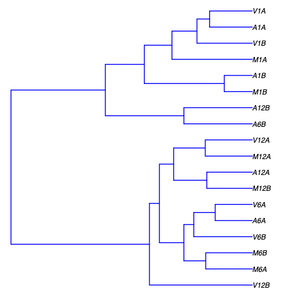

```r
knitr::include_graphics("png/hisat2_sample_tree.png")
```

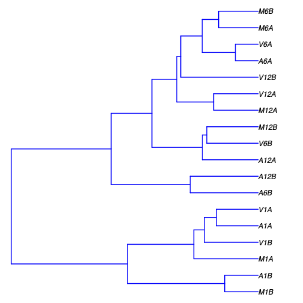

```r
knitr::include_graphics('png/bowtie2_sample_tree.png')
```

## Running edgeR for further analysis

```r
appendStep(finalProject) <- LineWise(code = {
  library(edgeR)
  countDF <- read.delim("results/bowtie2_countDFeByg.xls", row.names = 1,
                        check.names = FALSE)
  cmp <- readComp(stepsWF(finalProject)[["bowtie2_mapping"]], format = "matrix",
                  delim = "-")
  bowtie2_edgeDF <- run_edgeR(countDF = countDF, targets = targetsWF(finalProject)[["bowtie2_mapping"]],
                      cmp = cmp[[1]], independent = FALSE, mdsplot = "")
}, step_name = "bowtie2_run_edger", dependency = "bowtie2_read_counting")


appendStep(finalProject) <- LineWise(code = {
  library(edgeR)
  countDF <- read.delim("results/hisat2_countDFeByg.xls", row.names = 1,
                        check.names = FALSE)
  cmp <- readComp(stepsWF(finalProject)[["hisat2_mapping"]], format = "matrix",
                  delim = "-")
  hisat2_edgeDF <- run_edgeR(countDF = countDF, targets = targetsWF(finalProject)[["hisat2_mapping"]],
                      cmp = cmp[[1]], independent = FALSE, mdsplot = "")
}, step_name = "hisat2_run_edger", dependency = "hisat2_read_counting")
```

## Adding Gene descriptions

The gene discriptions are obtained from plants.ensembl.org **Information will be stored in edgeRglm_allcomp.xls**

```r
appendStep(finalProject) <- LineWise(code = {
  library("biomaRt")
  m <- useMart("plants_mart", dataset = "athaliana_eg_gene",
               host = "https://plants.ensembl.org")
  desc <- getBM(attributes = c("tair_locus", "description"),
                mart = m)
  desc <- desc[!duplicated(desc[, 1]), ]
  descv <- as.character(desc[, 2])
  names(descv) <- as.character(desc[, 1])
  bowtie2_edgeDF <- data.frame(bowtie2_edgeDF, Desc = descv[rownames(bowtie2_edgeDF)],
                       check.names = FALSE)
  write.table(bowtie2_edgeDF, "./results/bowtie2_edgeRglm_allcomp.xls", quote = FALSE,
              sep = "\t", col.names = NA)
}, step_name = "bowtie2_custom_annot",dependency = c("bowtie2_run_edger"))


appendStep(finalProject) <- LineWise(code = {
  library("biomaRt")
  m <- useMart("plants_mart", dataset = "athaliana_eg_gene",
               host = "https://plants.ensembl.org")
  desc <- getBM(attributes = c("tair_locus", "description"),
                mart = m)
  desc <- desc[!duplicated(desc[, 1]), ]
  descv <- as.character(desc[, 2])
  names(descv) <- as.character(desc[, 1])
  hisat2_edgeDF <- data.frame(hisat2_edgeDF, Desc = descv[rownames(hisat2_edgeDF)],
                       check.names = FALSE)
  write.table(hisat2_edgeDF, "./results/hisat2_edgeRglm_allcomp.xls", quote = FALSE,
              sep = "\t", col.names = NA)
}, step_name = "hisat2_custom_annot",dependency = c("hisat2_run_edger"))
```

**The filtered DEGs will be stored in DEGcounts.xls**

```r
appendStep(finalProject) <- LineWise(code = {
  bowtie2_edgeDF <- read.delim("results/bowtie2_edgeRglm_allcomp.xls", row.names = 1,
                       check.names = FALSE)
  pdf("results/bowtie2_DEGcounts.pdf")

  bowtie2_DEG_list <- filterDEGs(degDF = bowtie2_edgeDF, filter = c(Fold = 2,
                                                    FDR = 20))
  dev.off()
  write.table( bowtie2_DEG_list$Summary, "./results/bowtie2_DEGcounts.xls",
              quote = FALSE, sep = "\t", row.names = FALSE)
}, step_name = "bowtie2_filter_degs", dependency = "bowtie2_custom_annot")



appendStep(finalProject) <- LineWise(code = {
  hisat2_edgeDF <- read.delim("results/hisat2_edgeRglm_allcomp.xls", row.names = 1,
                       check.names = FALSE)
  pdf("results/hisat2_DEGcounts.pdf")
  hisat2_DEG_list <- filterDEGs(degDF = hisat2_edgeDF, filter = c(Fold = 2,
                                                    FDR = 20))
  dev.off()
  write.table(hisat2_DEG_list$Summary, "./results/hisat2_DEGcounts.xls",
              quote = FALSE, sep = "\t", row.names = FALSE)
}, step_name = "hisat2_filter_degs", dependency = "hisat2_custom_annot")
```

The output produced is an DEGcounts bar graph.

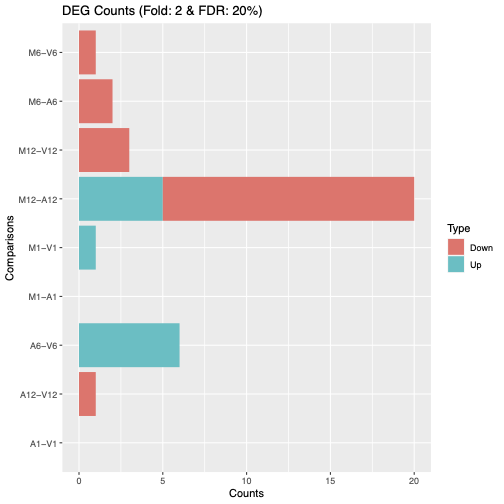

```r
knitr::include_graphics("png/hisat2_DEGcounts.png")
```

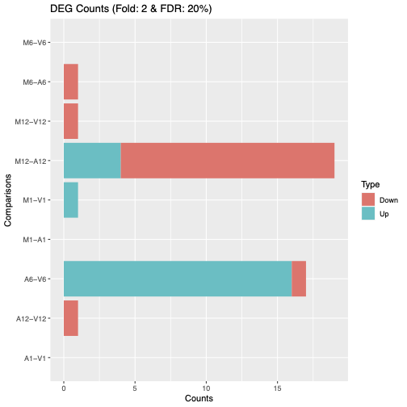

```r
knitr::include_graphics('png/bowtie2_DEGcounts.png')
```

Here we will peoduce venn diagrams

```r
appendStep(finalProject) <- LineWise(code = {
  bowtie2_vennsetup <- overLapper(bowtie2_DEG_list$Up[6:9], type = "vennsets")
  bowtie2_vennsetdown <- overLapper(bowtie2_DEG_list$Down[6:9], type = "vennsets")
  pdf("results/bowtie2_vennplot.pdf")
  vennPlot(list(bowtie2_vennsetup, bowtie2_vennsetdown), mymain = "", mysub = "",
           colmode = 2, ccol = c("blue", "red"))
  dev.off()
}, step_name = "bowtie2_venn_diagram", dependency = "bowtie2_filter_degs")


appendStep(finalProject) <- LineWise(code = {
  hisat2_vennsetup <- overLapper(hisat2_DEG_list$Up[6:9], type = "vennsets")
  hisat2_vennsetdown <- overLapper(hisat2_DEG_list$Down[6:9], type = "vennsets")
  pdf("results/hisat2_vennplot.pdf")
  vennPlot(list(hisat2_vennsetup, hisat2_vennsetdown), mymain = "", mysub = "",
           colmode = 2, ccol = c("blue", "red"))
  dev.off()
}, step_name = "hisat2_venn_diagram", dependency = "hisat2_filter_degs")
```

The output produced are venn Diagrams

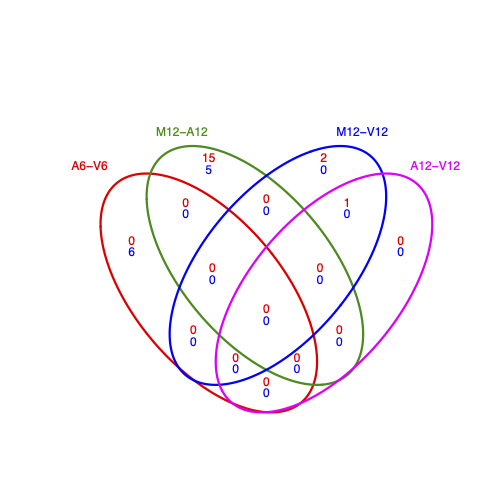

```r
knitr::include_graphics("png/hisat2_vennplot.png")
```

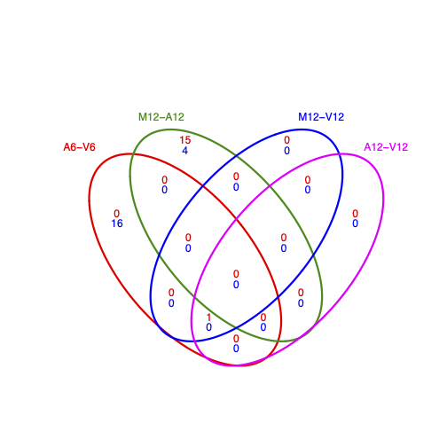

```r
knitr::include_graphics('png/bowtie2_vennplot.png')
```

## Gene Ontology (GO)

```r
appendStep(finalProject) <- LineWise(code = {
  library("biomaRt")
  listMarts() # To choose BioMart database
  listMarts(host='plants.ensembl.org')
  m <- useMart("plants_mart", host = "https://plants.ensembl.org")
  m <- useMart("plants_mart", dataset = "athaliana_eg_gene",
               host = "https://plants.ensembl.org")
  go <- getBM(attributes = c("go_id", "tair_locus", "namespace_1003"),
              mart = m)
  go <- go[go[, 3] != "", ]
  go[, 3] <- as.character(go[, 3])
  go[go[, 3] == "molecular_function", 3] <- "F"
  go[go[, 3] == "biological_process", 3] <- "P"
  go[go[, 3] == "cellular_component", 3] <- "C"
  go[1:4, ]
  if (!dir.exists("./data/GO"))
    dir.create("./data/GO")
  write.table(go, "data/GO/GOannotationsBiomart_mod.txt", quote = FALSE,
              row.names = FALSE, col.names = FALSE, sep = "\t")
  catdb <- makeCATdb(myfile = "data/GO/GOannotationsBiomart_mod.txt",
                     lib = NULL, org = "", colno = c(1, 2, 3), idconv = NULL)
  save(catdb, file = "data/GO/catdb.RData")
}, step_name = "get_go_annot", dependency = c("bowtie2_filter_degs","hisat2_filter_degs"))
```

## Go enrichment analysis

```r
appendStep(finalProject) <- LineWise(code = {
  library("biomaRt")
  load("data/GO/catdb.RData")
  bowtie2_DEG_list <- filterDEGs(degDF = bowtie2_edgeDF, filter = c(Fold = 2,
                                                    FDR = 50), plot = FALSE)
  up_down <- bowtie2_DEG_list$UporDown
  names(up_down) <- paste(names(up_down), "_up_down", sep = "")
  up <- bowtie2_DEG_list$Up
  names(up) <- paste(names(up), "_up", sep = "")
  down <- bowtie2_DEG_list$Down
  names(down) <- paste(names(down), "_down", sep = "")
  bowtie2_DEGlist <- c(up_down, up, down)
  bowtie2_DEGlist <- bowtie2_DEGlist[sapply(bowtie2_DEGlist, length) > 0]
  BatchResult <- GOCluster_Report(catdb = catdb, setlist = bowtie2_DEGlist,
                                  method = "all", id_type = "gene", CLSZ = 2, cutoff = 0.9,
                                  gocats = c("MF", "BP", "CC"), recordSpecGO = NULL)
  m <- useMart("plants_mart", dataset = "athaliana_eg_gene",
               host = "https://plants.ensembl.org")
  goslimvec <- as.character(getBM(attributes = c("goslim_goa_accession"),
                                  mart = m)[, 1])
  bowtie2_BatchResultslim <- GOCluster_Report(catdb = catdb, setlist = bowtie2_DEGlist,
                                      method = "slim", id_type = "gene", myslimv = goslimvec,
                                      CLSZ = 10, cutoff = 0.01, gocats = c("MF", "BP", "CC"),
                                      recordSpecGO = NULL)
  write.table(bowtie2_BatchResultslim, "results/bowtie2_GOBatchSlim.xls", row.names = FALSE,
              quote = FALSE, sep = "\t")
}, step_name = "bowtie2_go_enrich", dependency = "get_go_annot")




appendStep(finalProject) <- LineWise(code = {
  library("biomaRt")
  load("data/GO/catdb.RData")
  hisat2_DEG_list <- filterDEGs(degDF = hisat2_edgeDF, filter = c(Fold = 2,
                                                    FDR = 50), plot = FALSE)
  up_down <- hisat2_DEG_list$UporDown
  names(up_down) <- paste(names(up_down), "_up_down", sep = "")
  up <- hisat2_DEG_list$Up
  names(up) <- paste(names(up), "_up", sep = "")
  down <- hisat2_DEG_list$Down
  names(down) <- paste(names(down), "_down", sep = "")
  hisat2_DEGlist <- c(up_down, up, down)
  hisat2_DEGlist <- hisat2_DEGlist[sapply(hisat2_DEGlist, length) > 0]
  BatchResult <- GOCluster_Report(catdb = catdb, setlist = hisat2_DEGlist,
                                  method = "all", id_type = "gene", CLSZ = 2, cutoff = 0.9,
                                  gocats = c("MF", "BP", "CC"), recordSpecGO = NULL)
  m <- useMart("plants_mart", dataset = "athaliana_eg_gene",
               host = "https://plants.ensembl.org")
  goslimvec <- as.character(getBM(attributes = c("goslim_goa_accession"),
                                  mart = m)[, 1])
  hisat2_BatchResultslim <- GOCluster_Report(catdb = catdb, setlist = hisat2_DEGlist,
                                      method = "slim", id_type = "gene", myslimv = goslimvec,
                                      CLSZ = 10, cutoff = 0.01, gocats = c("MF", "BP", "CC"),
                                      recordSpecGO = NULL)
  write.table(hisat2_BatchResultslim, "results/hisat2_GOBatchSlim.xls", row.names = FALSE,
              quote = FALSE, sep = "\t")
}, step_name = "hisat2_go_enrich", dependency = "get_go_annot")
```

```r
DT::datatable(read.delim("results/bowtie2_GOBatchSlim.xls")[1:10, -10])
```

|  | CLID | CLSZ | GOID | NodeSize | SampleMatch | Phyper | Padj | Term | Ont |
| --- | --- | --- | --- | --- | --- | --- | --- | --- | --- |
| 1 | A6-V6_up_down | 39 | GO:0003723 | 2530 | 16 | 5.23312440819894e-07 | 1.30828110204973e-05 | RNA binding | MF |
| 2 | A6-V6_up_down | 39 | GO:0005198 | 587 | 6 | 0.000305743362214769 | 0.00764358405536922 | structural molecule activity | MF |
| 3 | A6-V6_up_down | 39 | GO:0003676 | 5183 | 17 | 0.00125258072130693 | 0.0313145180326732 | nucleic acid binding | MF |
| 4 | A6-V6_up_down | 39 | GO:0005215 | 1297 | 4 | 0.150373060613612 | 1 | transporter activity | MF |
| 5 | A6-V6_up_down | 39 | GO:0003824 | 9536 | 17 | 0.33119828338696 | 1 | catalytic activity | MF |
| 6 | A6-V6_up_down | 39 | GO:0008289 | 350 | 1 | 0.430602730650584 | 1 | lipid binding | MF |
| 7 | A6-V6_up_down | 39 | GO:0005488 | 15132 | 25 | 0.458302807412706 | 1 | binding | MF |
| 8 | A6-V6_up_down | 39 | GO:0000166 | 3141 | 4 | 0.757201057097365 | 1 | nucleotide binding | MF |
| 9 | A6-V6_up_down | 39 | GO:0016301 | 1456 | 1 | 0.909403722681864 | 1 | kinase activity | MF |
| 10 | A6-V6_up_down | 39 | GO:0003700 | 1653 | 1 | 0.93533636528135 | 1 | DNA-binding transcription factor activity | MF |

```r
DT::datatable(read.delim("results/hisat2_GOBatchSlim.xls")[1:10, -10])
```

|  | CLID | CLSZ | GOID | NodeSize | SampleMatch | Phyper | Padj | Term | Ont |
| --- | --- | --- | --- | --- | --- | --- | --- | --- | --- |
| 1 | A6-V6_up_down | 39 | GO:0003723 | 2530 | 16 | 5.23312440819894e-07 | 1.30828110204973e-05 | RNA binding | MF |
| 2 | A6-V6_up_down | 39 | GO:0005198 | 587 | 7 | 3.42026104469578e-05 | 0.000855065261173945 | structural molecule activity | MF |
| 3 | A6-V6_up_down | 39 | GO:0003676 | 5183 | 17 | 0.00125258072130693 | 0.0313145180326732 | nucleic acid binding | MF |
| 4 | A6-V6_up_down | 39 | GO:0005215 | 1297 | 3 | 0.342624376257246 | 1 | transporter activity | MF |
| 5 | A6-V6_up_down | 39 | GO:0008289 | 350 | 1 | 0.430602730650584 | 1 | lipid binding | MF |
| 6 | A6-V6_up_down | 39 | GO:0005488 | 15132 | 25 | 0.458302807412706 | 1 | binding | MF |
| 7 | A6-V6_up_down | 39 | GO:0003824 | 9536 | 16 | 0.458355693588228 | 1 | catalytic activity | MF |
| 8 | A6-V6_up_down | 39 | GO:0000166 | 3141 | 4 | 0.757201057097365 | 1 | nucleotide binding | MF |
| 9 | A6-V6_up_down | 39 | GO:0016301 | 1456 | 1 | 0.909403722681864 | 1 | kinase activity | MF |
| 10 | A6-V6_up_down | 39 | GO:0003700 | 1653 | 1 | 0.93533636528135 | 1 | DNA-binding transcription factor activity | MF |

## we can use the table to plot the results for each GO category (MF,BP,CC).

```r
appendStep(finalProject) <- LineWise(code = {
  gos <- bowtie2_BatchResultslim[grep("M6-V6_up_down", bowtie2_BatchResultslim$CLID),]
  gos <-bowtie2_BatchResultslim

  png("results/bowtie2_GOslimbarplotMF.png")
  goBarplot(gos, gocat = "MF")
  dev.off()
  png("results/bowtie2_GOslimbarplotBP.png")
  goBarplot(gos, gocat = "BP")
  dev.off()
  png("results/bowtie2_GOslimbarplotCC.png")
  goBarplot(gos, gocat = "CC")
  dev.off()
}, step_name = "bowtie2_go_plot", dependency = "bowtie2_go_enrich")


appendStep(finalProject) <- LineWise(code = {
  gos <- hisat2_BatchResultslim[grep("M6-V6_up_down", hisat2_BatchResultslim$CLID),]
  gos <-hisat2_BatchResultslim

  png("results/hisat2_GOslimbarplotMF.png")
  goBarplot(gos, gocat = "MF")
  dev.off()
  png("results/hisat2_GOslimbarplotBP.png")
  goBarplot(gos, gocat = "BP")
  dev.off()
  png("results/hisat2_GOslimbarplotCC.png")
  goBarplot(gos, gocat = "CC")
  dev.off()
}, step_name = "hisat2_go_plot", dependency = "hisat2_go_enrich")
```

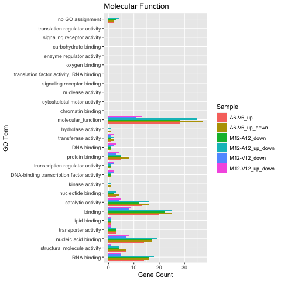

```r
knitr::include_graphics("results/hisat2_GOslimbarplotMF.png")
```

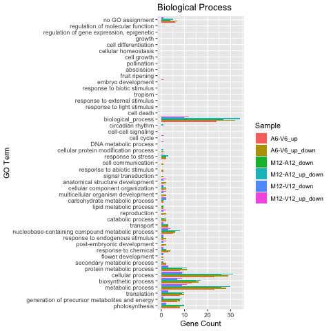

```r
knitr::include_graphics('results/hisat2_GOslimbarplotBP.png')
```

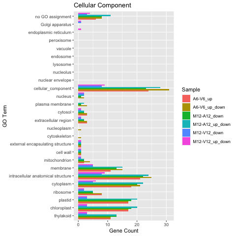

```r
knitr::include_graphics('results/hisat2_GOslimbarplotCC.png')
```

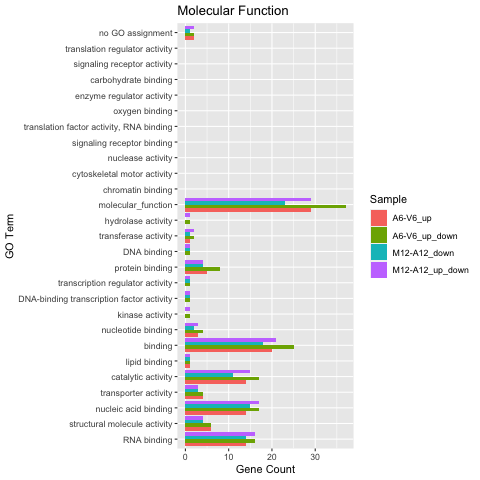

```r
knitr::include_graphics("results/bowtie2_GOslimbarplotMF.png")
```

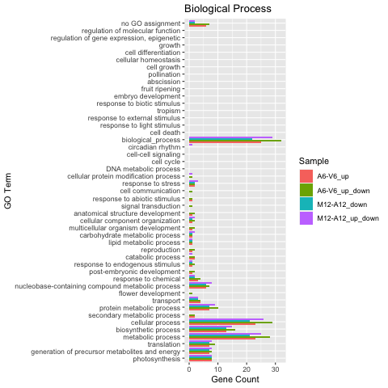

```r
knitr::include_graphics('results/bowtie2_GOslimbarplotBP.png')
```

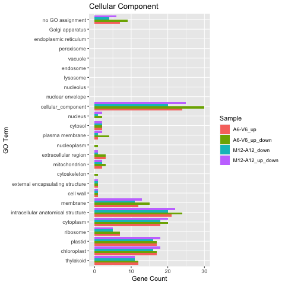

```r
knitr::include_graphics('results/bowtie2_GOslimbarplotCC.png')
```

```r
## Clustering and Heatmap
appendStep(finalProject) <- LineWise(code = {
  library(pheatmap)
  geneids <- unique(as.character(unlist(bowtie2_DEG_list[[1]])))
  y <- assay(rlog(dds))[geneids, ]
  pdf("results/bowtie2_heatmap.pdf")
  pheatmap(y, scale = "row", clustering_distance_rows = "correlation",
           clustering_distance_cols = "correlation")
  dev.off()
}, step_name = "bowtie2_heatmap", dependency = "bowtie2_go_enrich")


appendStep(finalProject) <- LineWise(code = {
  library(pheatmap)
  geneids <- unique(as.character(unlist(hisat2_DEG_list[[1]])))
  y <- assay(rlog(dds))[geneids, ]
  pdf("results/hisat2_heatmap.pdf")
  pheatmap(y, scale = "row", clustering_distance_rows = "correlation",
           clustering_distance_cols = "correlation")
  dev.off()
}, step_name = "hisat2_heatmap", dependency = "hisat2_go_enrich")


appendStep(finalProject) <- LineWise(code = {
  sessionInfo()
}, step_name = "sessionInfo", dependency = c("bowtie2_heatmap","hisat2_heatmap"))
```

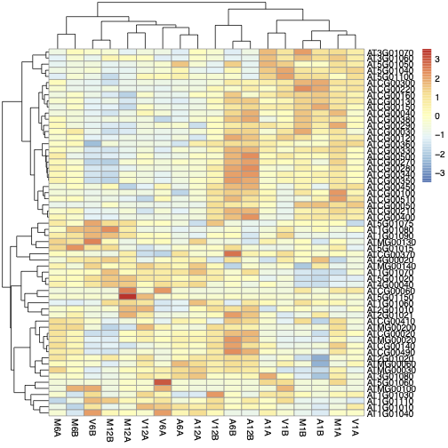

```r
knitr::include_graphics("png/hisat2_heatmap.png")
```

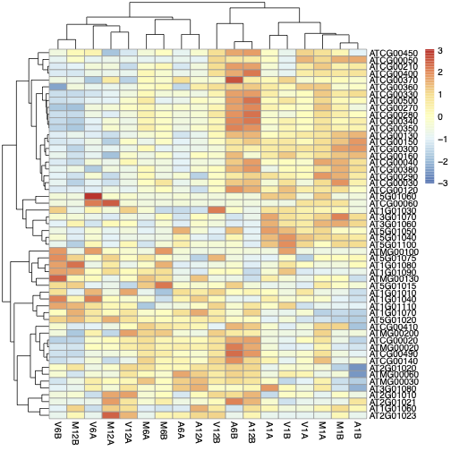

```r
knitr::include_graphics('png/bowtie2_heatmap.png')
```

## Now that all the steps are complete, we can run the project and see the output produced

```r
runWF(finalProject)
```

## Reporting System

This will render our logs and also print out the entire step of the project we have made

```r
renderLogs(finalProject)
plotWF(finalProject)
renderReport(finalProject)
```

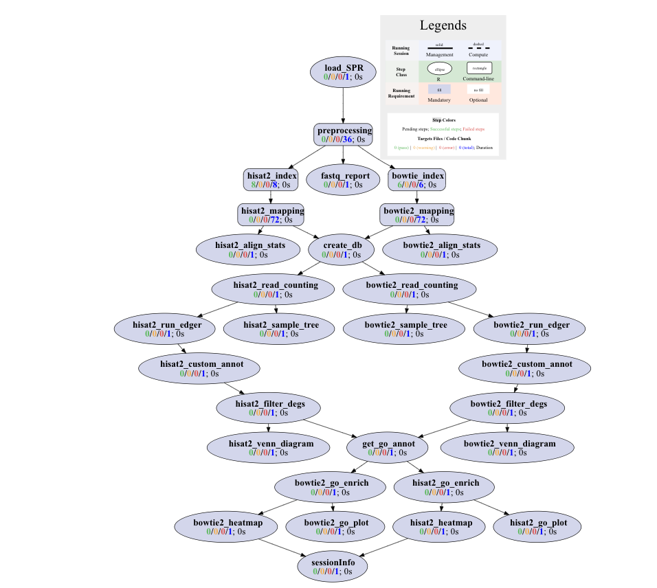

```r
knitr::include_graphics("png/projectSteps.png")
```